# 03-analyze_02-v01.R

aelhabr

Sun Dec 10 15:43:43 2017

## “Competition Type” Analysis

### What are the score distributions for each competition type?

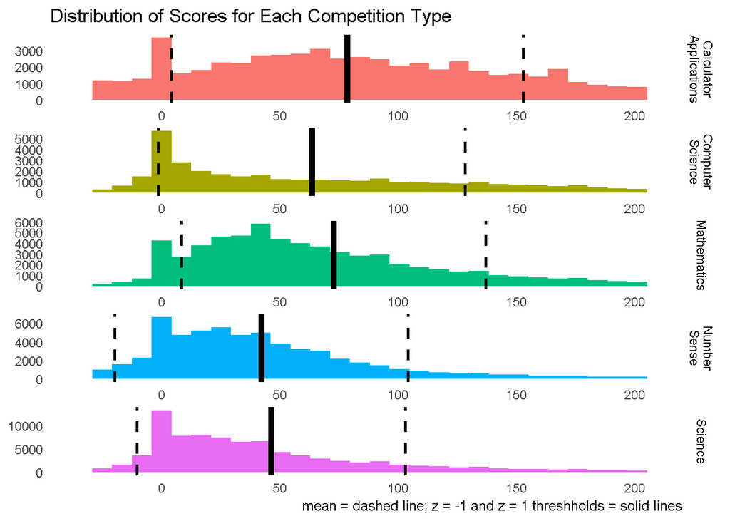

### What are the score distributions for each competition type *by year* and *by competition level*?

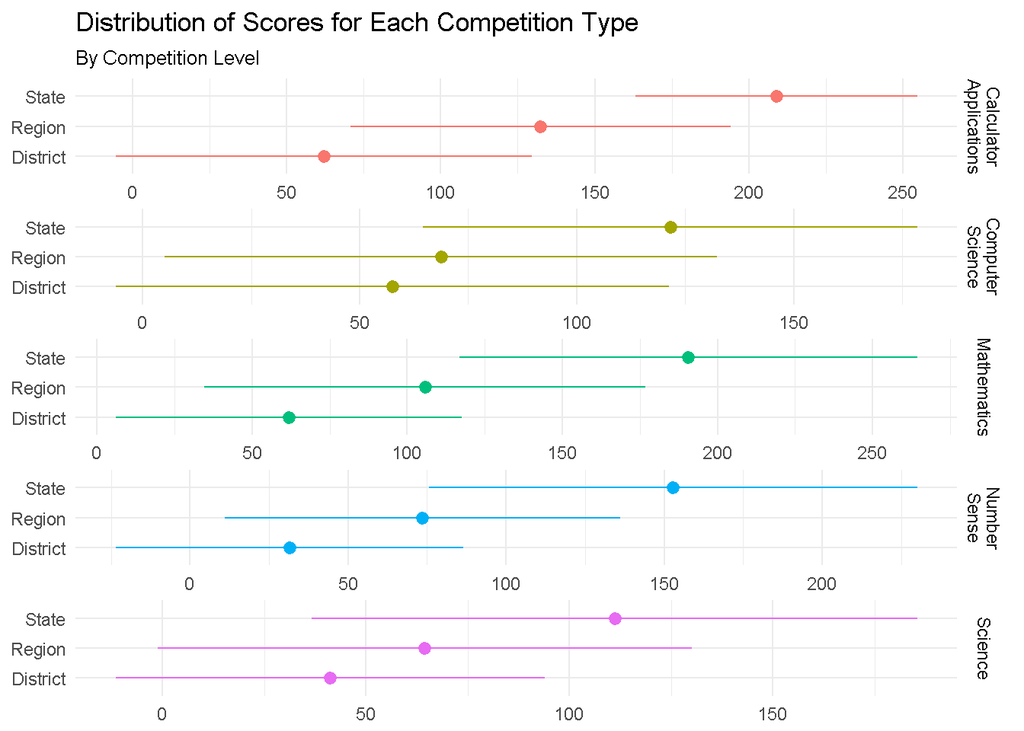

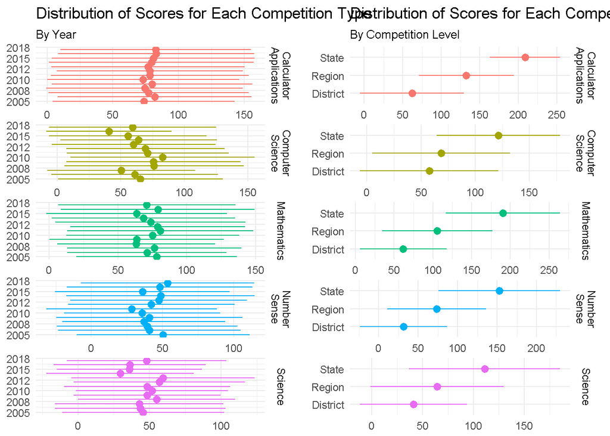

It appears that there is no discernable trends among score distributions across years. Nonetheless, it is evident that score range distributions shift upwards with increasing competition level, as would be expected with more “superior” competitors advancing to higher levels of competition.

The lack of pattern in score distributions over time is a strong indication that the tests have about the same difficulty every year. This implies that it would not be unreasonable to compare raw test scores for a given competition type when comparing individuals and schools across different years. (Nonetheless, I account for year-t0-year variation in my calculations.)

### Which competition types have the largest increase in scores with increasing competition level?

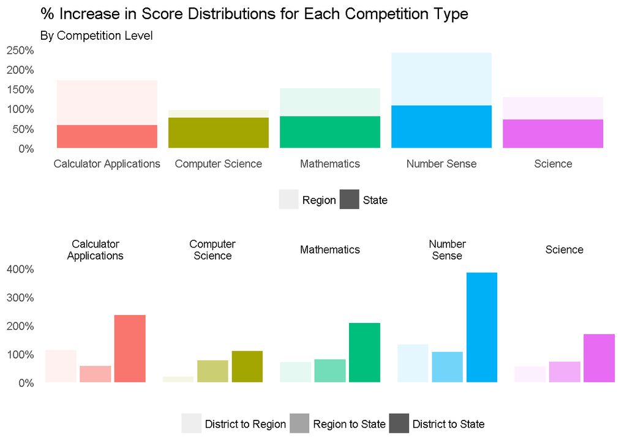

It appears that `Number Sense` demonstrates the largest “jumps” in aggregate scores with increasing competition levels. Having competed in this competition before, I do not find this all too suprising. More than any other competition type, those who succeed `Number Sense` rely on natural abilities (as opposed to training) to “beat out” the competition. Often times, this “natural ability” can be deemed “savant”-like. Consequently, with increasing competition level, is is more likely that these “superior” competitors stand out, and, as observed here, skew the scoring distributions higher with less “inferior” competitors to weight down the averages.

### Have the score distribution differences at each competition level changed over time?

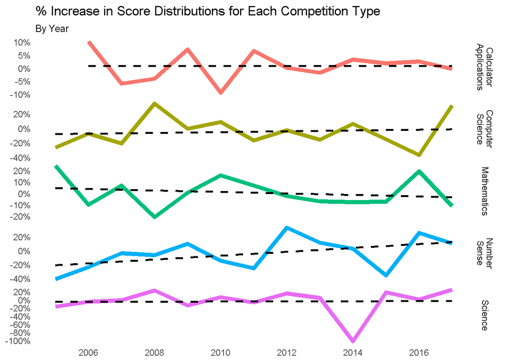

There could be a number of confounding factors engendering the relatively even competition level of time. For example, test makers may have made tests more difficult if competitors were observed to have increased their skill levels. The converse coulde be true as well. Or, most likely, test makers and competition skill level have stayed relatively the same over time. If this is the case, at the very least we can say that the academic “elite” of newer generations have not dropped off in terms of academic prowess (although nothing can be dedcued about those who do not compete in UIL academic competitions).